# Analysing US Airport Temperature Trends

# Introduction

This is an analysis looking at long-term trends in temperature recorded at US airport stations. I orginally did this about a year ago, but am re-visiting it in more detail and with improved R and data science skills.

# Data

- In original analysis, I had downloaded all the files to my computer and was loading/combining them from there.
- I have now downloaded and cleaned all the data, and put into a sqlite database that I will query from instead of reading in the csv files.
- See https://github.com/andypicke/wunderground_data

# Methods

- My plan is to fit a linear regression to long-term temperature records at each airport station.
- I will try doing this a variety of ways: Using all (daily) data, and using monthly/yearly averaged data.
- I will display the results (the slope of the linear regression) on a leaflet map, with the size and color of points mapped to the magnitude of the trend.

## Figure out how to query the data for 1 station from the database

- http://www.datacarpentry.org/R-ecology-lesson/05-r-and-databases.html
- Note The src_sqlite() command does not load the data into the R session ; use *collect*

```r
library(ggplot2)
suppressPackageStartupMessages( library(dplyr) )
# open connection to sql database
db_path <- '/Users/Andy/Projects/wunderground_data/wunderground_daily.db'
wea_db <- src_sqlite(db_path)
wea_db
```

```
src:  sqlite 3.19.3 [/Users/Andy/Projects/wunderground_data/wunderground_daily.db]
tbls: wea, wea_clean
```

## Example Querying w/ SQL

```r
tbl(wea_db, sql("SELECT * FROM wea_clean WHERE mean_temp NOT NULL LIMIT 10"))
```

| date | st_code | max_temp | min_temp | mean_temp | year | yday | month | precip_In | cloud_cover | max_gust_mph | events |
| --- | --- | --- | --- | --- | --- | --- | --- | --- | --- | --- | --- |
| 2000-05-29 00:00:00 | PARL | 57 | 44 | 48 | 2000 | 150 | 5 | 0 | 4 | 18 | Rain |
| 2000-06-15 00:00:00 | PARL | 60 | 51 | 56 | 2000 | 167 | 6 | 0 | 7 | 24 | Rain |
| 2000-06-20 00:00:00 | PARL | 64 | 57 | 60 | 2000 | 172 | 6 | 0 | 4 | 17 | NA |
| 2000-06-26 00:00:00 | PARL | 75 | 66 | 70 | 2000 | 178 | 6 | 0 | 6 | 21 | NA |
| 2000-08-02 00:00:00 | PARL | 78 | 50 | 64 | 2000 | 215 | 8 | 0 | 6 | 17 | NA |
| 2000-09-12 00:00:00 | PARL | 51 | 35 | 43 | 2000 | 256 | 9 | 0 | 6 | 21 | Snow |
| 2000-09-18 00:00:00 | PARL | 39 | 24 | 32 | 2000 | 262 | 9 | 0 | 5 | 15 | Fog-Snow |
| 2000-09-22 00:00:00 | PARL | 53 | 48 | 50 | 2000 | 266 | 9 | 0 | 6 | 21 | Rain |
| 2001-05-01 00:00:00 | PARL | 46 | 17 | 32 | 2001 | 121 | 5 | 0 | 6 | 30 | Snow |
| 2001-05-27 00:00:00 | PARL | 62 | 48 | 55 | 2001 | 147 | 5 | 0 | 4 | 21 | NA |

## Example querying w/ dplyr

```r
wea_df <- tbl(wea_db,'wea_clean') %>%
        filter(st_code=='KDEN' & between(year,2008,2010) & !is.na(yday)) %>%
        select(date,year,yday,mean_temp) %>%
        collect()

head(wea_df)
```

| date | year | yday | mean_temp |
| --- | --- | --- | --- |
| 2008-01-01 00:00:00 | 2008 | 1 | 11 |
| 2008-01-02 00:00:00 | 2008 | 2 | 19 |
| 2008-01-03 00:00:00 | 2008 | 3 | 42 |
| 2008-01-04 00:00:00 | 2008 | 4 | 44 |
| 2008-01-05 00:00:00 | 2008 | 5 | 42 |
| 2008-01-06 00:00:00 | 2008 | 6 | 35 |

## Get all data for specified station and year range

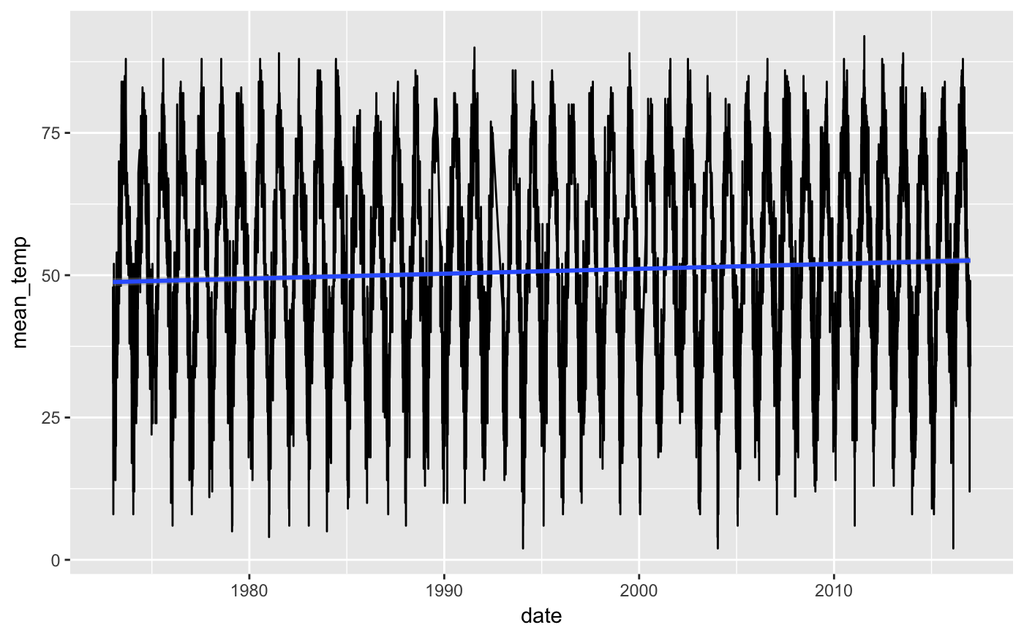

```r
the_sta <- 'KBOS'
year1 <- 1950
year2 <- 2016
wea_df <- tbl(wea_db,'wea_clean') %>%
        filter(st_code==the_sta & between(year,year1,year2) & !is.na(yday)) %>%
        select(date,st_code,year,yday,mean_temp) %>%
        collect()
wea_df$date <- as.Date(wea_df$date)
#head(wea_df)
wea_df %>%  ggplot(aes(date,mean_temp)) +
        geom_line() +
        geom_smooth(method='lm')
```

## Compute yearly average temps

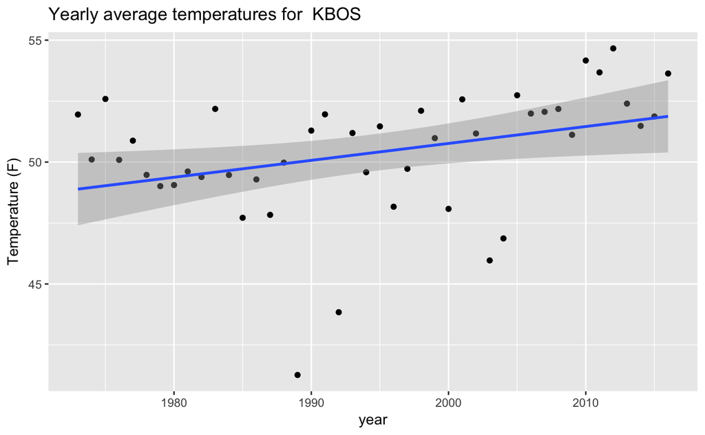

```r
the_sta <- 'KBOS'
year1 <- 1950
year2 <- 2016
wea_yearly <- tbl(wea_db,'wea_clean') %>%
        filter(st_code==the_sta & between(year,year1,year2) & !is.na(yday)) %>%
        distinct() %>%
        select(date,st_code,year,yday,mean_temp) %>%
        group_by(year) %>%
        summarise(mt = mean(mean_temp)) %>%
        collect()
wea_yearly %>%  ggplot(aes(year,mt)) +
        geom_point() +
        geom_smooth(method='lm') +
        ggtitle(paste('Yearly average temperatures for ',the_sta)) +
        ylab('Temperature (F)')
```

```r
tbl(wea_db, sql("SELECT count(distinct(st_code)) as N_stations  FROM wea_clean"))
```

| N_stations |
| --- |
| 1592 |

# Trends in yearly-avgerage temperatures

- Compute yearly average temperatures
- - Need to make sure we have good data for entire years?
- fit linear regression and find trend (slope)

## First, see how many years have complete or almost complete data

```r
the_sta <- 'KBOS'
year1 <- 1950
year2 <- 2016
wea_yearly <- tbl(wea_db,'wea_clean') %>%
        filter(st_code==the_sta & between(year,year1,year2) & !is.na(yday)) %>%
        distinct() %>%
        select(date,st_code,year,yday,mean_temp) %>%
        group_by(year) %>%
        summarise(mt = mean(mean_temp), N=count()) %>%
        collect()
#        filter(N>300) %>%
#        collect()
wea_yearly
```

| year | mt | N |
| --- | --- | --- |
| 1973 | 51.95067 | 223 |
| 1974 | 50.10502 | 219 |
| 1975 | 52.58974 | 195 |
| 1976 | 50.09055 | 254 |
| 1977 | 50.87805 | 246 |
| 1978 | 49.47479 | 238 |
| 1979 | 49.01333 | 225 |
| 1980 | 49.05785 | 242 |
| 1981 | 49.61304 | 230 |
| 1982 | 49.38785 | 214 |

[output cut: 34 more lines]

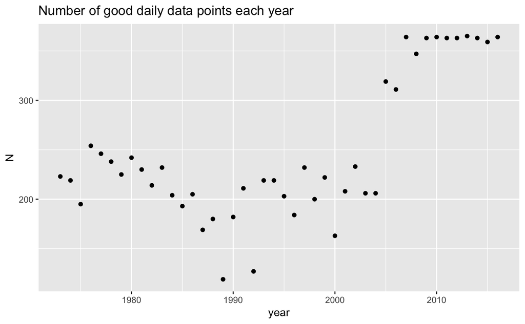

```r
wea_yearly %>% ggplot(aes(year,N)) +
        geom_point() +
        ggtitle('Number of good daily data points each year')
```

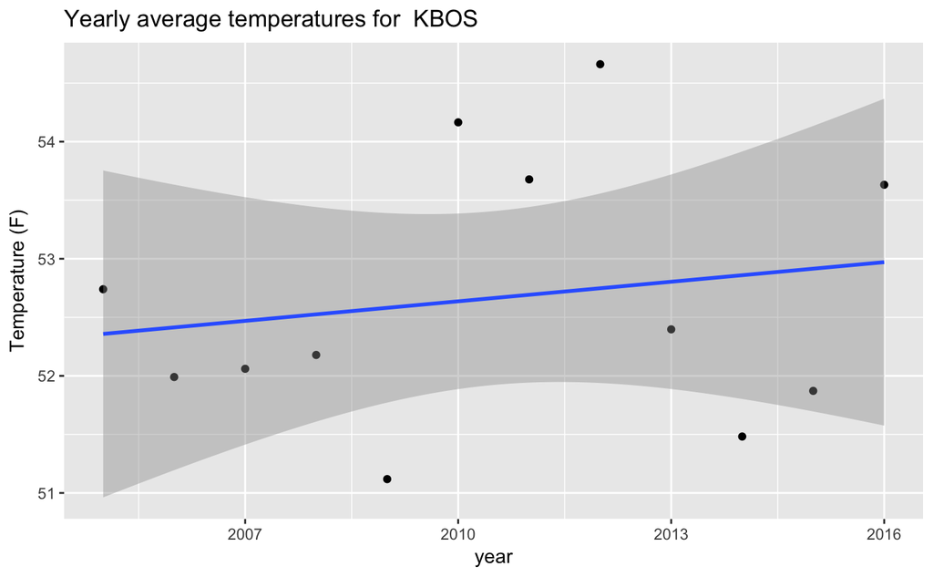

```r
the_sta <- 'KBOS'
year1 <- 1950
year2 <- 2016
wea_yearly <- tbl(wea_db,'wea_clean') %>%
        filter(st_code==the_sta & between(year,year1,year2) & !is.na(yday)) %>%
        distinct() %>%
        select(date,st_code,year,yday,mean_temp) %>%
        group_by(year) %>%
        summarise(mt = mean(mean_temp), N=count()) %>%
        filter(N>300) %>%
        collect()
wea_yearly %>%  ggplot(aes(year,mt)) +
        geom_point() +
        geom_smooth(method='lm') +
        ggtitle(paste('Yearly average temperatures for ',the_sta)) +
        ylab('Temperature (F)')
```

```r
mod <- lm(mt~year,data = wea_yearly)
summary(mod)
```

```
Call:
lm(formula = mt ~ year, data = wea_yearly)

Residuals:
    Min      1Q  Median      3Q     Max
-1.4625 -0.5785 -0.3766  0.7420  1.9131

Coefficients:
             Estimate Std. Error t value Pr(>|t|)
(Intercept) -59.33078  193.93203  -0.306    0.766
year          0.05571    0.09646   0.577    0.576

Residual standard error: 1.153 on 10 degrees of freedom
Multiple R-squared:  0.03227,   Adjusted R-squared:  -0.0645
F-statistic: 0.3335 on 1 and 10 DF,  p-value: 0.5764
```